# Open Science Workflow Training for ISC – day-1-pres-reproducible_environments

Reproducible R Environments

Megumi Oshima & Nicholas Ducharme-Barth

January 2025

## What is an R environment?

- Everything needed to run your code correctly:
  - R
  - R packages (and their dependencies)
  - System dependencies (e.g. external software)

## What does it mean to be reproducible?

- The version of R is recorded
- The versions of every package are recorded
- The versions of system dependencies are recorded

## Signs you want to use a reproducible R environment

- Code that used to run no longer runs even though you haven’t changed the code itself
- You upgrade to a new version of a package and things break
- You want to easily share your code with a colloaborator
- You want to run your code in somewhere besides your local computer
- You have different projects that use different versions of the same package

## How can we do this?

[`renv`](https://rstudio.github.io/renv/) is an R package to help create reproducible environments

[figure not shown]

## renv

- Isloated - each project has it’s own library
- Portable - easy to install on different computers (even OS)
- Reproducible - ensures you are using the exact package versions

## Project libraries

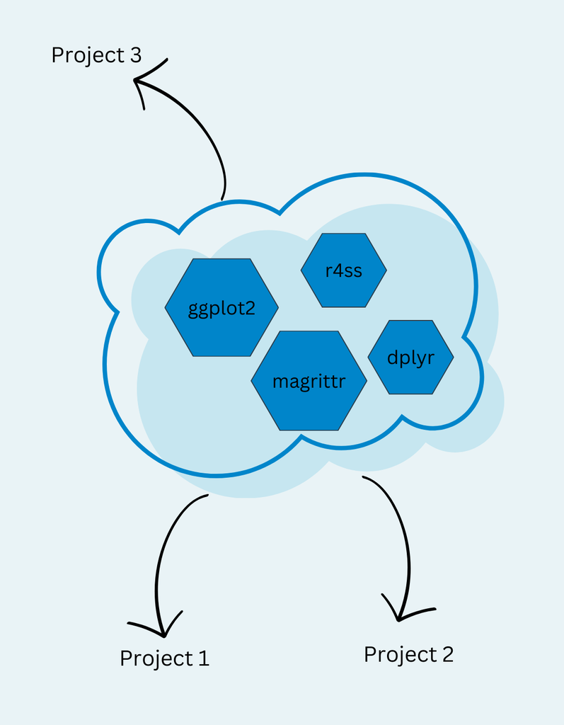

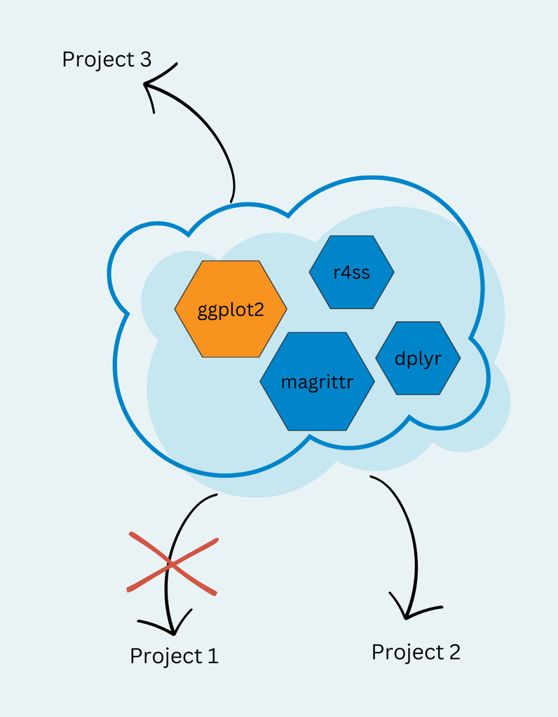

[figure not shown]

## renv Workflow

[figure not shown]

## Initalize project

- When you first start a project, you will want to initialize a renv project

`renv::init()`

- Creates 3 items:

`renv/library/`

`renv.lock`

`.Rprofile`

## Installing new packages

`renv::install()` - can specify the location and version you want

As you install new packages you will need to update the lockfile

## Using the lockfile for collaboration

`renv::snapshot()` - updates lockfile with metadata about all currently-used packages

`renv::restore()` - reproduces the environment specified in the lockfile

## Another use for renv

- Can use a lockfile for GitHub Actions (or other continuous integration systems)
- Use the r-lib `setup-renv` action in your workflow

```yaml
jobs:
  build-deploy:
    runs-on: ubuntu-latest
    steps:
    - name: Install packages using renv
      uses: r-lib/actions/setup-renv@v2
```

# Questions

## Resources

- [Introduction to renv](https://rstudio.github.io/renv/articles/renv.html)
- [Using renv in GitHub Actions](https://rstudio.github.io/renv/articles/ci.html)